# Mustakis_Athena_HW3

### Homework 3

Athena Mustakis

#### Problem 1

Consider a one-dimensional random walker that can move every second. With probability pl = 1/3 it moves to the left, with probability pr = 1/3 it moves to right, and with probability ps = 1/3 it rests/stays and does not move. Assuming at time t = 0, the random walker is at x = 0, plot the probability density function and the cumulative probability function for t = 10, t = 100, and t = 1000 seconds. Make just two plots; each showing all three time points. Remember that you need to simulate random walks many times to get good statistics. Make the same two plots for pl = 0, pr = 1/2, and ps = 1/2. Do you understand why these plots look different? The plots that you make should be designed well. For example, they should label curves, axes, etc.

```python
import random #import as the neccessary things needed like random, numpy, and matplot lib
import numpy as np
import matplotlib.pyplot as plt
class base_walker:
    def __init__(self):
        pass
    def one_step(self):
        pass
    def steps(self,n=1):
        for i in range(n):
            self.one_step()
```

```python
#stimulate multiple random walks
#each walk has 1000 steps
```

```python
class random_walker(base_walker):
    def __init__(self):
        # define stored variables, initial data
        pass
    def one_step(self):
        # increment the current position by +1 or -1, with equal probability
        # use random.random() - generates a random number uniformly between 0 and 1
        pass
    def get_walk(self):
        # return the history of the position of the walker
        pass
```

```python
class random_walker(base_walker):
    def __init__(self):
        # define stored variables, initial data
        self.x = 0
        self.walk = [self.x]
    def one_step(self):
        # increment the current position by +1 or -1, with equal probability
        rand = random.random() #chooses a random value between 0 and 1
        #do bins to break up 1 into thirds to do the probability
        if rand < 0.33: #if its less 0.3 it moves to the right
            self.x += 1
        if rand > 0.33 and rand < 0.66:
            self.x -= 1 #if its greater than 0.3 and less than 0.66 it moves to the left
        else:
            self.x += 0 #else it stays the same
        self.walk.append(self.x)
    def get_walk(self):
        # return the history of the position of the walker
        return self.walk
```

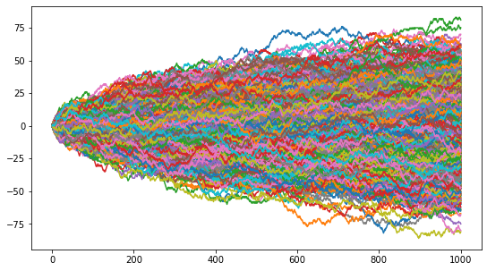

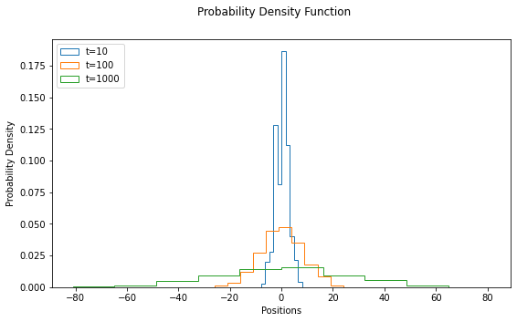

```python
import matplotlib.pyplot as plt
num_walks = 1500 # perform random walk a bunch of times so that statisitics are good

total_positions = [] # will contain positions of all 1500 walks


for i in range(num_walks): # perform 1500 walks
    walker = random_walker()
    walker.steps(1000)
    walk = walker.get_walk() #call the methods in the class
    total_positions.append(walk)
    label.append('random walk ' + str(i+1)) # add 1 so the first walk is walk 1 and not 0


for i in range(num_walks):  #plotting all the multiple runs of the random walker into one plot
    walk = total_positions[i]
    label.append('random walk ' + str(i+1)) # add 1 so the first walk is walk 1 and not 0
    plt.plot(walk)

ten =[] #create seperate lists for the time positions that we want which is 10, 100, and 1000
hundred = []
thousand = []
for k in total_positions: #its a nested loop and we need to call out the specific positions so use a for loop in order to achieve this
    ten.append(k[10]) #append the elements you pulled out to the specific lists that we made
    hundred.append(k[100])
    thousand.append(k[1000])

#creating the probability density function
fig, ax = plt.subplots() #use subplot so that we can plot those three times as histograms in one plot
ax.hist(ten, histtype='step', density=True, label="t=10") #use the label in order to set up the legend
ax.hist(hundred, histtype='step', density=True, label = "t=100")
ax.hist(thousand, histtype='step', density=True, label= "t=1000")
fig.suptitle("Probability Density Function")
plt.xlabel("Positions")
plt.ylabel("Probability Density")
plt.legend(loc = "upper left") #place the legend in the upper left corner so that it is easier to read
```

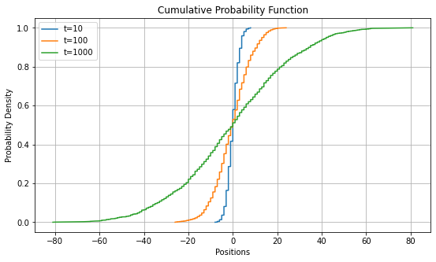

```python
#creating the cumulative probability function
sorted_ten = np.sort(ten) #sort all the values that are in the list for each time frame
sorted_hundred = np.sort(hundred)
sorted_thousand = np.sort(thousand)
fig, ax = plt.subplots()

yten= 1. * np.arange(len(ten))/(len(ten)-1) #calculate the proportional values of the samples
yhundred = 1. * np.arange(len(hundred))/(len(hundred)-1)
ythousand = 1. * np.arange(len(thousand))/(len(thousand)-1)
ax.plot(sorted_ten, yten,label = "t=10") #plot each line using subplot
ax.plot(sorted_hundred, yhundred,label = "t=100")
ax.plot(sorted_thousand, ythousand,label = "t=1000")
plt.ylabel('Probability Density')
plt.xlabel('Positions')
plt.title('Cumulative Probability Function');
plt.legend(loc= "upper left")
plt.grid()
```

```python
#now do the same process but now the probability of going left is 0, the probability of going right is 0.5 and staying the same is 0.5
#so use the same process as above but only have one if and else statement since probability of going left is 0 we dont even need to put it in
#so if it is > 0.5 it will move to the right else it will stay the same
```

```python
import random
import numpy as np
import matplotlib.pyplot as plt
#now do the same process as above but only move right and stay the same bc there is 0 probability it moves to the left
#so set it up that if its less than 0.5 it moves to the right and if it is more than 0.5 then it stays the same
class random_walk(base_walker):
    def __init__(self):
        # define stored variables, initial data
        pass
    def one_step(self):
        # increment the current position by +1 or -1, with equal probability
        # use random.random() - generates a random number uniformly between 0 and 1
        pass
    def get_walk(self):
        # return the history of the position of the walker
        pass
```

```python
class random_walk(base_walker):
    def __init__(self):
        # define stored variables, initial data
        self.x = 0
        self.walk = [self.x]
    def one_step(self):
        # increment the current position by +1 or -1, with equal probability
        rand = random.random()
        if rand > 0.5: #if its less than 0.5 then it moves to the right
            self.x += 1
        else:
            self.x += 0 #or else it stays the same since the probability to move to the left is 0 so its options are to move right or stay the same
        self.walk.append(self.x)
    def get_walk(self):
        # return the history of the position of the walker
        return self.walk
```

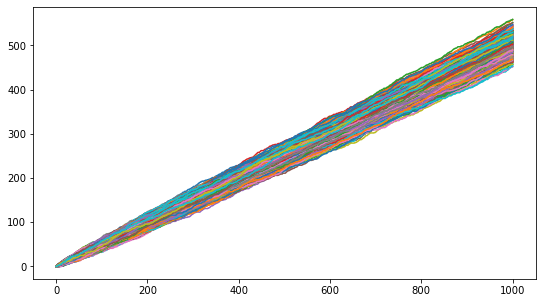

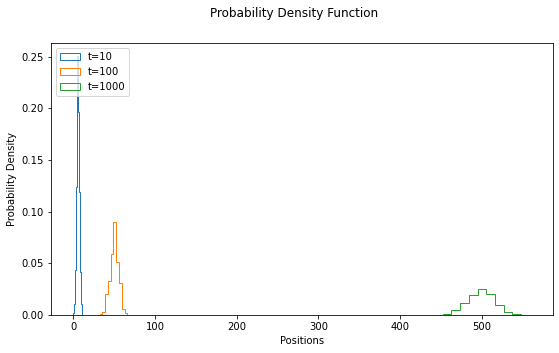

```python
import matplotlib.pyplot as plt
num_walks = 1500 # perform random walk 100 times so statitics are good

total_positions = [] # will contain positions of all 10 walks
label = [] # for creating the legend

for i in range(num_walks): # perform 10 walks
    walker = random_walk()
    walker.steps(1000)
    walk = walker.get_walk()
    total_positions.append(walk)
    label.append('random walk ' + str(i+1)) # add 1 so the first walk is walk 1 and not 0

for i in range(num_walks):
    walk = total_positions[i]
    label.append('random walk ' + str(i+1)) # add 1 so the first walk is walk 1 and not 0
    plt.plot(walk)

ten2 =[] #create lists to store certain time points values to use to plot
hundred2 = []
thousand2 = []
for k in total_positions: #use a for loop to get the elements out of the nested for loop
    ten2.append(k[10])
    hundred2.append(k[100])
    thousand2.append(k[1000])

fig, ax = plt.subplots()
ax.hist(ten2, histtype='step', density=True, label = "t=10")
ax.hist(hundred2, histtype='step', density=True, label = "t=100")
ax.hist(thousand2, histtype='step', density=True, label= "t=1000")
fig.suptitle("Probability Density Function")
plt.xlabel("Positions")
plt.ylabel("Probability Density")
plt.legend(loc = "upper left")
```

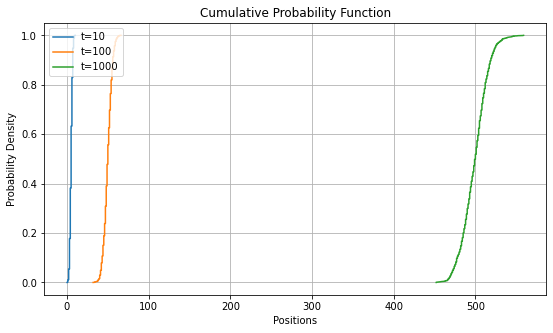

```python
#repeated the same process as 1/3 probabilities
sorted_ten2 = np.sort(ten2)
sorted_hundred2 = np.sort(hundred2)
sorted_thousand2 = np.sort(thousand2)
fig, ax = plt.subplots()

yten2= 1. * np.arange(len(ten2))/(len(ten2)-1)
yhundred2 = 1. * np.arange(len(hundred2))/(len(hundred2)-1)
ythousand2 = 1. * np.arange(len(thousand2))/(len(thousand2)-1)
ax.plot(sorted_ten2, yten2,label = "t=10")
ax.plot(sorted_hundred2, yhundred2,label = "t=100")
ax.plot(sorted_thousand2, ythousand2,label = "t=1000")
plt.ylabel('Probability Density')
plt.xlabel('Positions')
plt.title('Cumulative Probability Function');
plt.legend(loc= "upper left")
plt.grid()
```

In the 1/3 probabilities it centers around 0 because there is an equal chance that it moves left right and stays the same. This is why on the plot there are negative and positive values and all three of the time plots are centered around the same values because of the probabilty. When in the second part when it is 0 probability that it moves to the left and 0.5 that it moves to the right and 0.5 that it says in the same position, the probability is no longer equal for how it moves. Which is why on the histogram it is no longer centered at 0 because it either increases or stays the same the value never becomes negative, which is why each time plotted is at a different position because they increase or stay the same but never go back. The plots look different because one the movement is by equal probabities when for the second they are unequal.